## List of questions

```
##  [1] "What 3 words would you use to describe our lab culture?"
##  [2] "What do you like most about working here?"
##  [3] "What do you like least about working here?"
##  [4] "How happy are you in the lab?"
##  [5] "Is there something that could be provided to make you happier?"
##  [6] "What is your impression of social life in the lab?"
##  [7] "If you want to improve the social life in the lab, what are your suggestions for achieving this?"
##  [8] "How comfortable do you feel sharing personal concerns (housing, financial, family, physical or mental health) with Nico?"
##  [9] "Do you feel explicit or implicit pressure to work more hours than you feel is healthy?"
## [10] "Do you feel explicit or implicit pressure to publish?"
## [11] "Do you feel explicit or implicit pressure to avoid taking vacations?"
## [12] "If you feel pressured, does this pressure have negative effects on you well being and productivity?"
## [13] "What can we do to reduce these pressures?"
## [14] "Have you experienced or witnessed a hostile work environment in the lab? (bullying, gender harassment, sexual harassment)"
## [15] "How well does the lab communicate as a whole?"
```

[output cut: 45 more lines]

### “3 words to describ the lab culture”

```
## [1] "multidimensional, high lab functioning, high diversity,open, flexible, service-oriented,healthy distance, funny,Supportive, organised, strict,Independent, sometimes no free slot to work in the lab, organized,large_team, diverse, cooperative,supportive, welcoming,fun, together, open,interesti…
```

[interactive chart not shown]

### “What do you like most about working here?”

```
## [1] "Work independently while having time to listen to podcasts and getting things done. supportive people and the ability to follow your own schedule.. people are approachable, people help each other, there are many people to interact with. open-, kindness. colleagues are very helpful. The resea…
```

### “What do you like least about working here?”

```
## [1] "sometimes lack of thinking along. There seems to be a lack of a real team-spirit sometimes / in some respects.. lack of a computing lab. Involved in many different projects we do not have a lot of expertise. People seem to never be relaxed/chilled, unwilling to spend time here beyond actual …
```

### “How happy are you in the lab?”

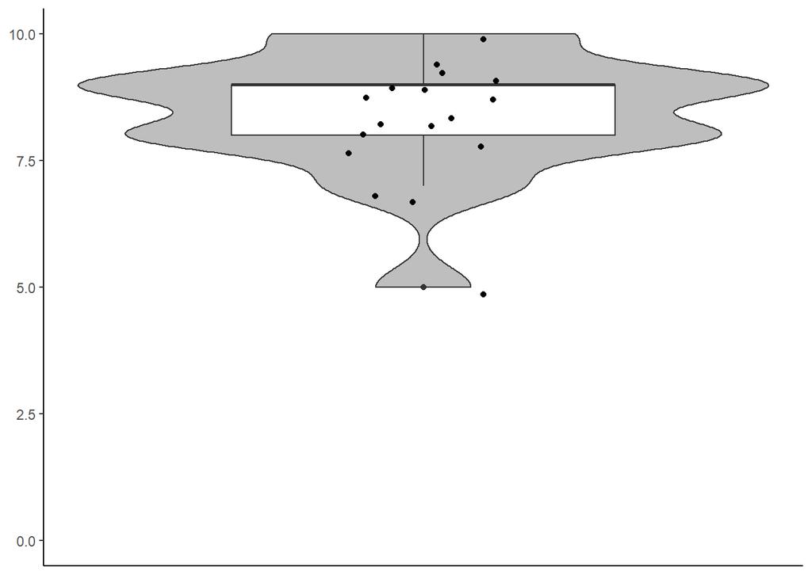

### “Is there something that could be provided to make you happier?”

```
## [1] "better waste recycling system (also in the labs). more events together, e.g. online boardgame evenings or other work-less meetings. Properly plan some group social time bit more often after Corona. More interactions with direct project supervisors. I haven’t talked to mine in more than 6 mon…
```

### “What is your impression of social life in the lab?”

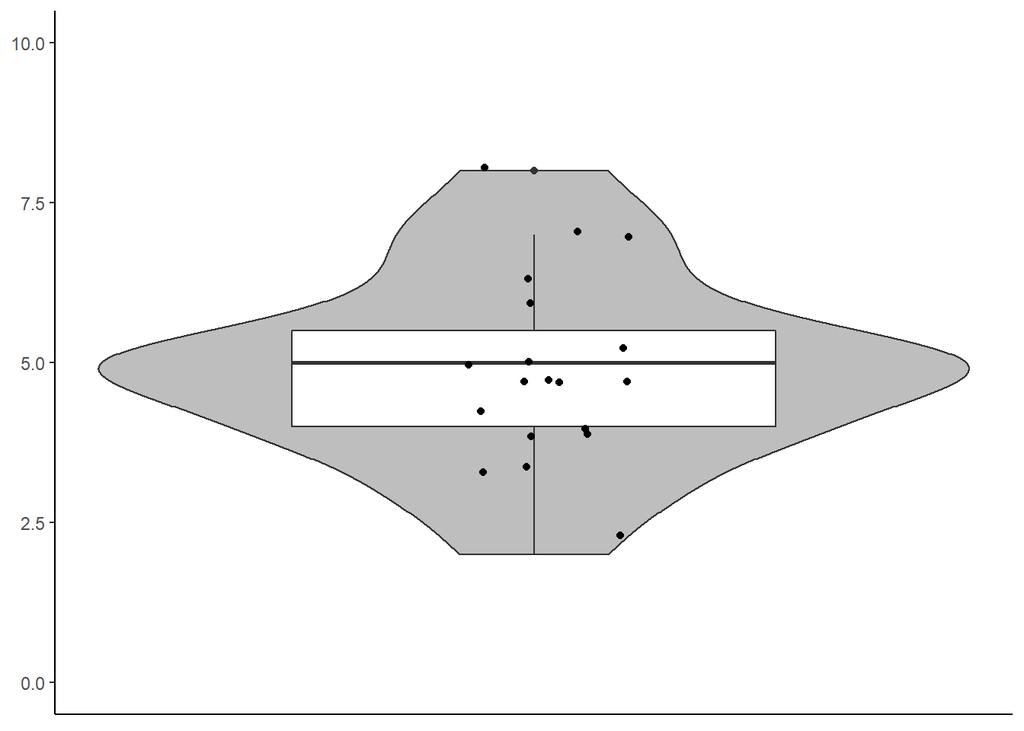

### “If you want to improve the social life in the lab, what are your suggestions for achieving this?”

```
## [1] "weekly beer outside the institute, informing each other on what one works atm (I think Nico planned this for the lab seminar anyway). More social events, but probybly also more dedication from everyone. Hard during covid-19 of course, but in general: more activities together. mandatory activ…
```

### “How comfortable do you feel sharing personal concerns (housing, financial, family, physical or mental health) with Nico?”

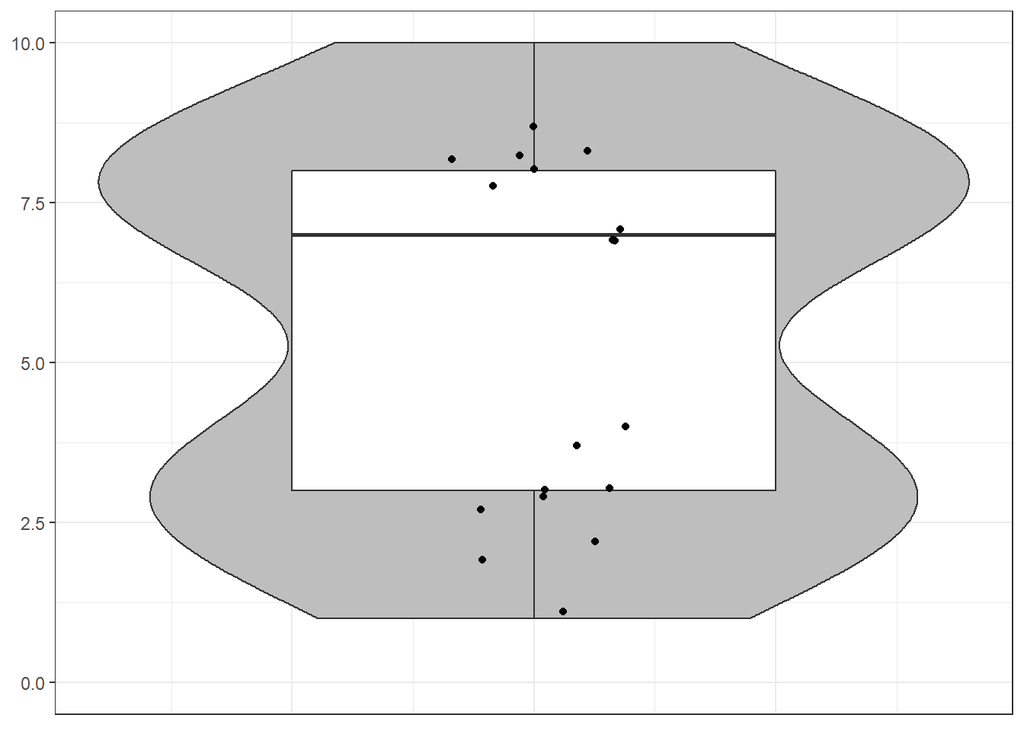

### Pressure

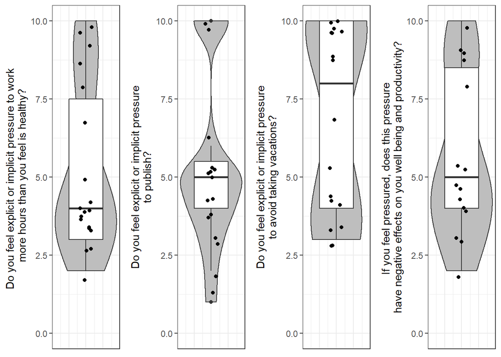

```
## [1] "chill. have clear agreements with unpaid thesis students about vacations/days off/days away /long weekends and how much work is expected (eg. 40h week, 30h week..). Change the all academic system. Hard to not compare with others in places like iDiv when the media only highlight Science paper…
```

### Harassment

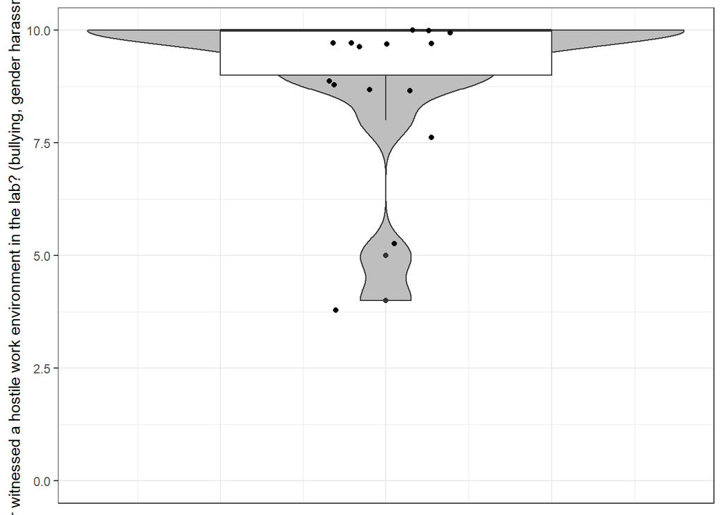

### Communication

#### “How well does the lab communicate as a whole?”

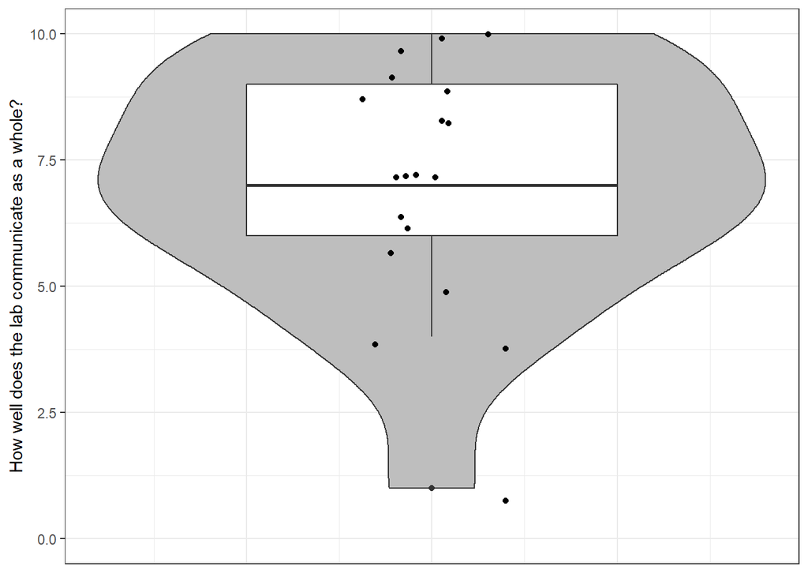

#### “What are some ways that we could improve communication in the lab?”

```
## [1] "bringing people together, not only when related to work itself (more small talks, chats). Slack is a good initiative; more personal interactions would be good as soon as allowed. Decrease time infront of screens, fixed times to do sport/yoga/lunch together. Also one hike a month. Decrease pr…
```

### Lab rules

#### “Do you feel that lab rules/policies are clear? Are there unspoken rules or policies that you feel should be more clearly communicated?”

```
## [1] "I think they are clear, there are some How-to's - the info is there, just needs to be read.. most rules and policies are clear. For me, rules are quite clear and always well communicated, I think especially Alfred is doing a really good job here.. yes, they are clear - for all of the ones I …
```

#### “Are there policies you feel should be explicitly written? If so, please explain which ones.”

```
## [1] "consequeces in case of misbehaviour. no. respect each others personal space of being. be kind and ask others how they are ?. No.. No.. no. Examples for waste disposal of chemicals (esp. for students with not much knowledge about chemicals used in the lab). No. no"
```

#### “Do you feel that the same rules apply to everyone in lab? If not, please explain.”

```
## [1] "yes. yes. yes. The same rules do not apply to everyone. I think there is a big difference between scientists and non-scientists. Not all of this can actually be changed. and it is better than in some other labs I think.. If people ask for more \"freedom\" they will get it.. Yes. Yes. no, e.g…
```

### Empowerement

```
##  No Yes
##   4  15
```

#### “Do you feel empowered to make suggestions to Nico to improve the lab culture/ organization?”

```
##  No Yes
##   3  16
```

#### “If you do not feel empowered to make suggestions to your colleagues in the lab or to Nico to improve the lab culture/ organization, please tell me more about this.”

```
## [1] "openness towards new people by all colleagues not just by Nico. limitied direct interaction, only few personal meetings. -. -. Because of hierarchies. Me as a student tried to suggest some things to other students/coworkers without effect. I am not sure everyone feels like this.. Some collea…
```

### Supervision

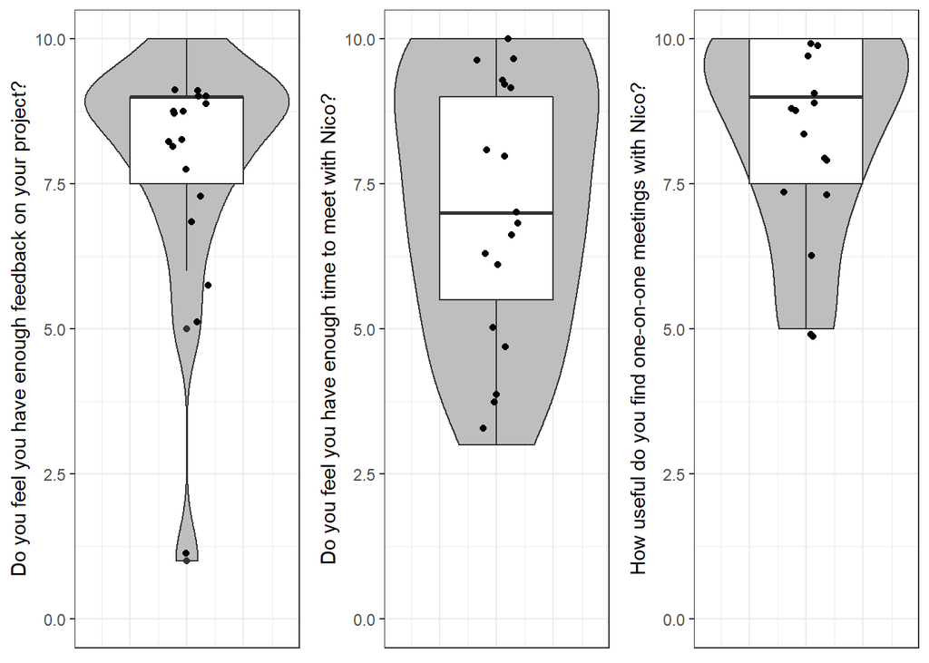

#### “Is there something that could make these meetings more useful or productive?”

```
## [1] "The meetings are usually very time-limited due to other meetings of Nico. Usually, it is not possible to cover all the topics that I wanted to discuss.. for me, they are not necessary so far. but I know they will help me if I need them. I had some good and bad meetings.. More regular. that t…
```

#### “Do you think the current system of scheduling one-on-one meetings is working? Should these be less frequent, more frequent, or stay as is?”

```
## [1] "working!. stay as is. I feel like that there is always room to schedule meetings, i think it can stay as it is.. Scheduling one-on-one meetings works.. yes, there is a threshold between more time and more frequency. I would prefer more time with the same frequency.. Most of the meetings I ha…
```

#### “Do you think you would benefit from more formal feedback on your progress?”

```
## [1] "there is already a lot. no. always! but it is also clear that Nico and other supervisors don't have a 30h day to do everything. No. yes. - never had a meeting, no use for me -. Yes. no. no. No, I usually feel that the informal meetings give me quite a good idea in my progress and what to do …
```

#### “How supported do you feel by Nico, and do you think that you are getting the mentoring, career advice, and general guidance to succeed?”

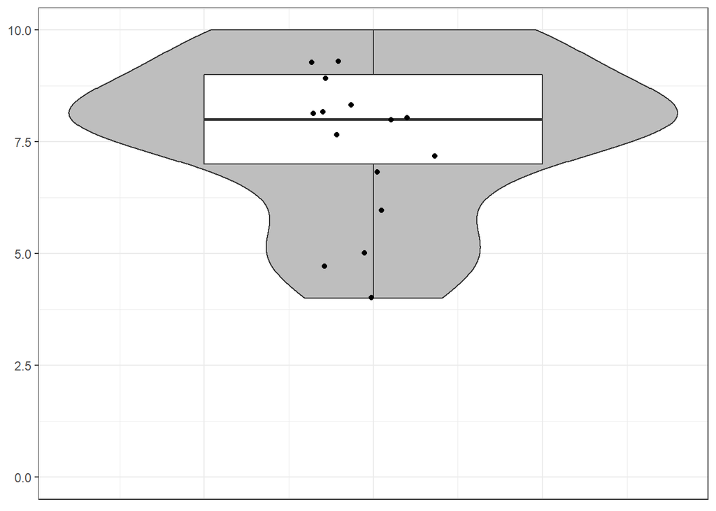

#### “Do you want formal training in giving talks?”

```
##   No  Yes NA's
##   11    6    2
```

#### “Do you want to have more than an Annual Mentoring Meeting to go over your Individual Development Plan and discuss post-PhD or post-Postdoc plans?”

```
##   No  Yes NA's
##    8    5    6
```

#### “What kind of advice or information would be useful to discuss at such an Annual Mentoring Meeting?”

```
## [1] "career profile in terms of research topics. Possibilities and how to fit in Scientific world. strategic advice about project and/or publications. These meetings are important, but I do not like them as I do not feel that I do make progress. But this is not the fault of Nico.. possibilties of…
```

#### “Do you have any explicit feedback on how Nico can improve his mentoring style?”

```
## [1] "There are dozens of workshop offers for how to lead/manage a lab group and teach a lot of tools for time management and self-organisation that could be good advice for lab members. Very young group leaders often take this opportunity to get a bit more professional on this.. no. no. One examp…
```

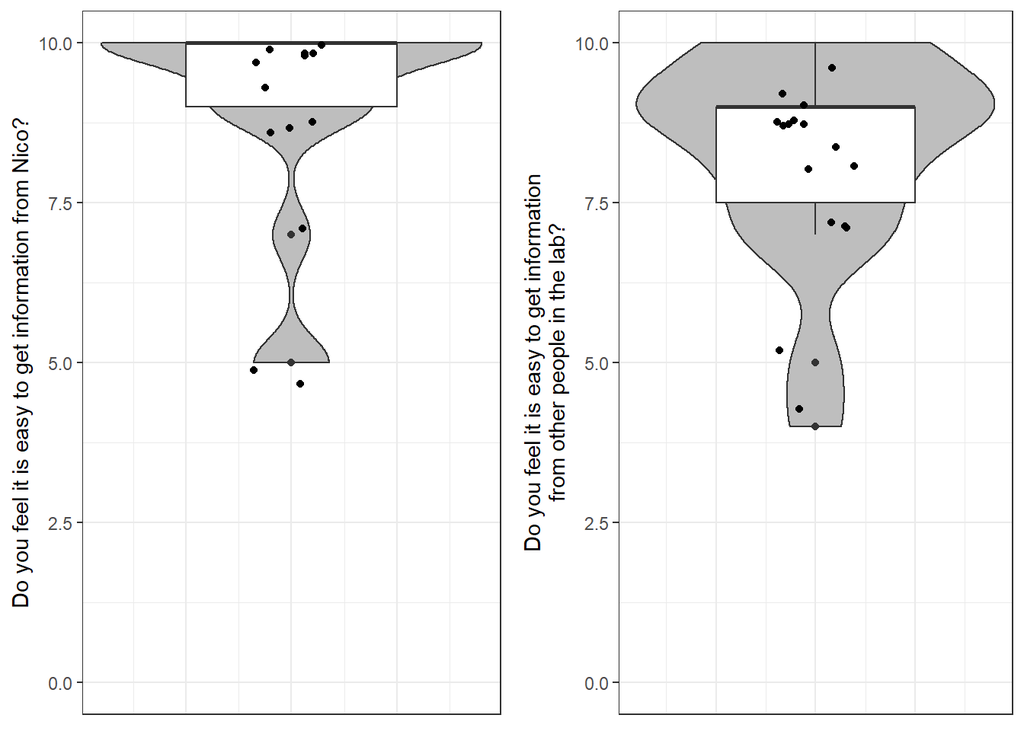